# Network indices of the Florentine families weddings network

We shall compute several indices of the Florentine families weddings network. We shall use the **igraph** package, and the network’s adjacency matrix **flo** that comes with the **network** package. Therefore we start by attaching both packages (which I have already installed) and loading the data:

```r
library(network)
library(igraph)
library(printr)   #to display matrices and tables nicely
data(flo)
```

Let’s check the matrix:

```r
flo
```

|  | Acciaiuoli | Albizzi | Barbadori | Bischeri | Castellani | Ginori | Guadagni | Lamberteschi | Medici | Pazzi | Peruzzi | Pucci | Ridolfi | Salviati | Strozzi | Tornabuoni |
| --- | --- | --- | --- | --- | --- | --- | --- | --- | --- | --- | --- | --- | --- | --- | --- | --- |
| Acciaiuoli | 0 | 0 | 0 | 0 | 0 | 0 | 0 | 0 | 1 | 0 | 0 | 0 | 0 | 0 | 0 | 0 |
| Albizzi | 0 | 0 | 0 | 0 | 0 | 1 | 1 | 0 | 1 | 0 | 0 | 0 | 0 | 0 | 0 | 0 |
| Barbadori | 0 | 0 | 0 | 0 | 1 | 0 | 0 | 0 | 1 | 0 | 0 | 0 | 0 | 0 | 0 | 0 |
| Bischeri | 0 | 0 | 0 | 0 | 0 | 0 | 1 | 0 | 0 | 0 | 1 | 0 | 0 | 0 | 1 | 0 |
| Castellani | 0 | 0 | 1 | 0 | 0 | 0 | 0 | 0 | 0 | 0 | 1 | 0 | 0 | 0 | 1 | 0 |
| Ginori | 0 | 1 | 0 | 0 | 0 | 0 | 0 | 0 | 0 | 0 | 0 | 0 | 0 | 0 | 0 | 0 |
| Guadagni | 0 | 1 | 0 | 1 | 0 | 0 | 0 | 1 | 0 | 0 | 0 | 0 | 0 | 0 | 0 | 1 |
| Lamberteschi | 0 | 0 | 0 | 0 | 0 | 0 | 1 | 0 | 0 | 0 | 0 | 0 | 0 | 0 | 0 | 0 |
| Medici | 1 | 1 | 1 | 0 | 0 | 0 | 0 | 0 | 0 | 0 | 0 | 0 | 1 | 1 | 0 | 1 |
| Pazzi | 0 | 0 | 0 | 0 | 0 | 0 | 0 | 0 | 0 | 0 | 0 | 0 | 0 | 1 | 0 | 0 |
| Peruzzi | 0 | 0 | 0 | 1 | 1 | 0 | 0 | 0 | 0 | 0 | 0 | 0 | 0 | 0 | 1 | 0 |
| Pucci | 0 | 0 | 0 | 0 | 0 | 0 | 0 | 0 | 0 | 0 | 0 | 0 | 0 | 0 | 0 | 0 |
| Ridolfi | 0 | 0 | 0 | 0 | 0 | 0 | 0 | 0 | 1 | 0 | 0 | 0 | 0 | 0 | 1 | 1 |
| Salviati | 0 | 0 | 0 | 0 | 0 | 0 | 0 | 0 | 1 | 1 | 0 | 0 | 0 | 0 | 0 | 0 |
| Strozzi | 0 | 0 | 0 | 1 | 1 | 0 | 0 | 0 | 0 | 0 | 1 | 0 | 1 | 0 | 0 | 0 |
| Tornabuoni | 0 | 0 | 0 | 0 | 0 | 0 | 1 | 0 | 1 | 0 | 0 | 0 | 1 | 0 | 0 | 0 |

Now we define a graph from this adjacency matrix

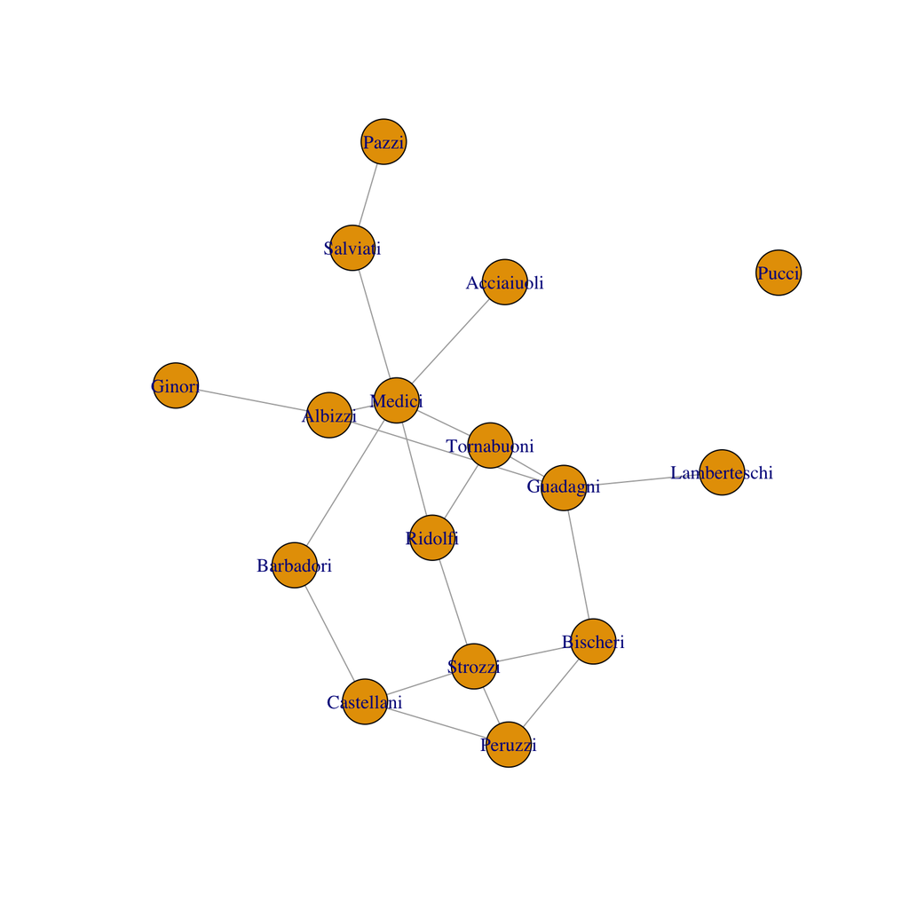

```r
FLO=graph_from_adjacency_matrix(flo,mode="undirected")
plot(FLO)
```

```r
#To improve the representation, see the available parameters in help(igraph.plotting)
```

It has two connected components, as we can confirm with:

```r
components(FLO)$no
```

```
## [1] 2
```

```r
components(FLO)$csize
```

```
## [1] 15  1
```

```r
groups(components(FLO))
```

```
## $`1`
##  [1] "Acciaiuoli"   "Albizzi"      "Barbadori"    "Bischeri"
##  [5] "Castellani"   "Ginori"       "Guadagni"     "Lamberteschi"
##  [9] "Medici"       "Pazzi"        "Peruzzi"      "Ridolfi"
## [13] "Salviati"     "Strozzi"      "Tornabuoni"
##
## $`2`
## [1] "Pucci"
```

From now on, we shall restrict ourselves to the “giant component”, excluding the Pucci. We can do it in two ways: removing the corresponding node (with **delete_vertices**) or taking the subgraph induced by the nodes in the giant component (with **induced_subgraph**):

Removing the Pucci:

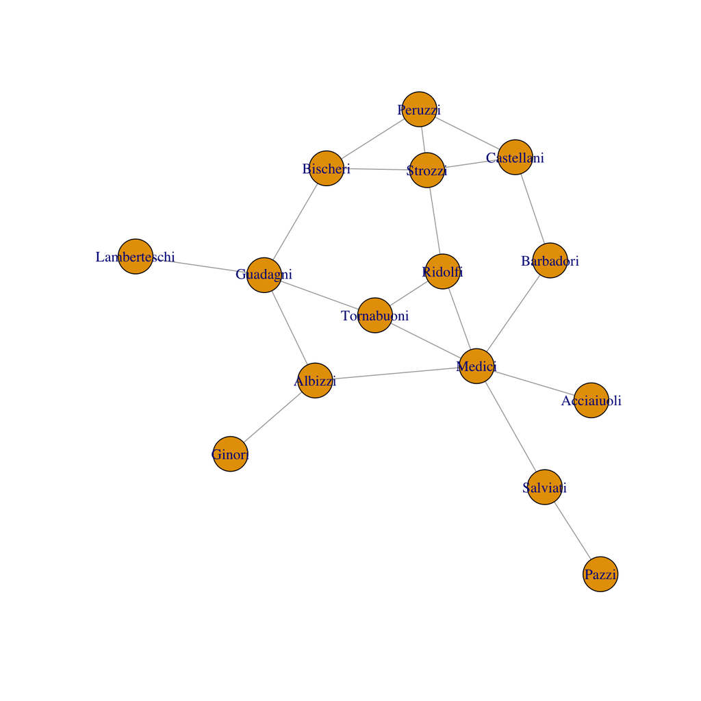

```r
FLOp=delete_vertices(FLO,"Pucci")
plot(FLOp)
```

Taking the subgraph:

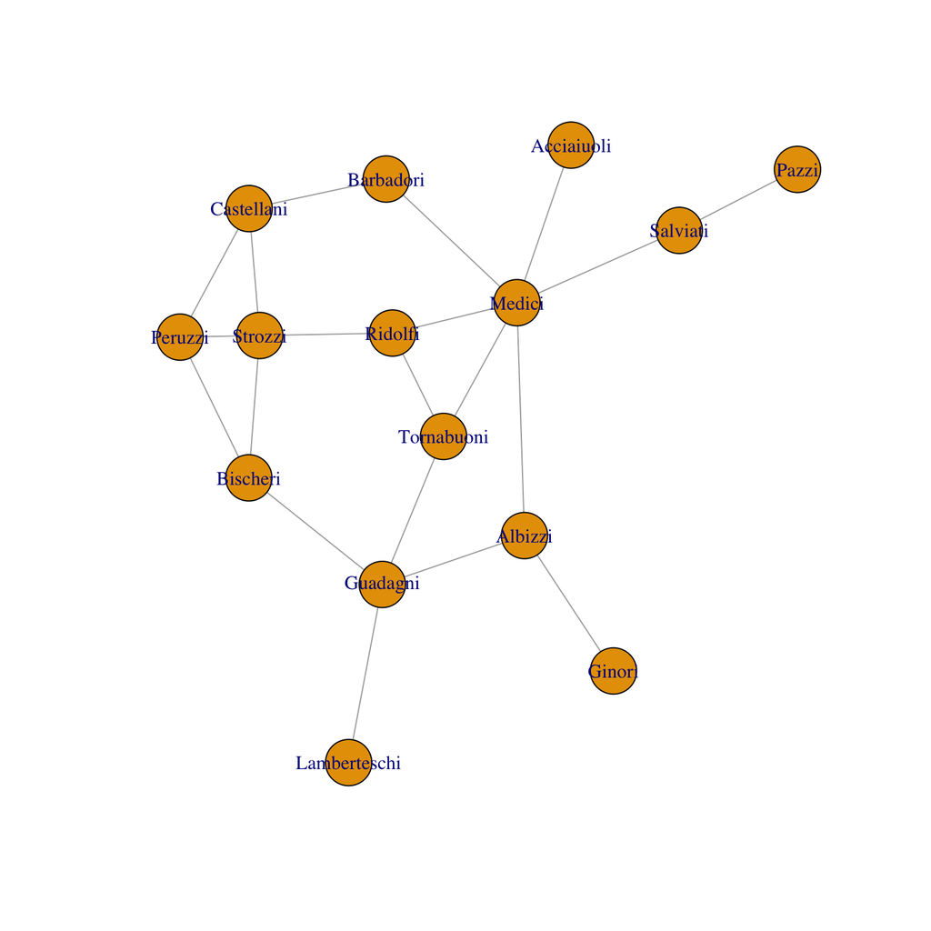

```r
FLOpp=induced_subgraph(FLO,v=groups(components(FLO))[[1]])
plot(FLOpp)
```

Both graphs are the same:

```r
is_isomorphic_to(FLOp,FLOpp)
```

```
## [1] TRUE
```

We shall work from now on with **FLOp**. Let’s compute its vectors of nodes and edges, its order, its size, and its adjacency matrix:

```r
V(FLOp)  #The nodes
```

```
## + 15/15 vertices, named:
##  [1] Acciaiuoli   Albizzi      Barbadori    Bischeri     Castellani
##  [6] Ginori       Guadagni     Lamberteschi Medici       Pazzi
## [11] Peruzzi      Ridolfi      Salviati     Strozzi      Tornabuoni
```

```r
VF=as_ids(V(FLOp))
VF
```

```
##  [1] "Acciaiuoli"   "Albizzi"      "Barbadori"    "Bischeri"
##  [5] "Castellani"   "Ginori"       "Guadagni"     "Lamberteschi"
##  [9] "Medici"       "Pazzi"        "Peruzzi"      "Ridolfi"
## [13] "Salviati"     "Strozzi"      "Tornabuoni"
```

```r
EF=as_ids(E(FLOp)) #The edges
EF
```

```
##  [1] "Acciaiuoli|Medici"     "Albizzi|Ginori"
##  [3] "Albizzi|Guadagni"      "Albizzi|Medici"
##  [5] "Barbadori|Castellani"  "Barbadori|Medici"
##  [7] "Bischeri|Guadagni"     "Bischeri|Peruzzi"
##  [9] "Bischeri|Strozzi"      "Castellani|Peruzzi"
## [11] "Castellani|Strozzi"    "Guadagni|Lamberteschi"
## [13] "Guadagni|Tornabuoni"   "Medici|Ridolfi"
## [15] "Medici|Salviati"       "Medici|Tornabuoni"
## [17] "Pazzi|Salviati"        "Peruzzi|Strozzi"
## [19] "Ridolfi|Strozzi"       "Ridolfi|Tornabuoni"
```

```r
n=gorder(FLOp) #The order, that is, length(VF)
m=gsize(FLOp) #The size, that is, length(EF)
```

The order of the connected component graph is 15 and the size 20. As far as the adjacency matrix, it is:

```r
M=as.matrix(as_adjacency_matrix(FLOp))
M
```

|  | Acciaiuoli | Albizzi | Barbadori | Bischeri | Castellani | Ginori | Guadagni | Lamberteschi | Medici | Pazzi | Peruzzi | Ridolfi | Salviati | Strozzi | Tornabuoni |
| --- | --- | --- | --- | --- | --- | --- | --- | --- | --- | --- | --- | --- | --- | --- | --- |
| Acciaiuoli | 0 | 0 | 0 | 0 | 0 | 0 | 0 | 0 | 1 | 0 | 0 | 0 | 0 | 0 | 0 |
| Albizzi | 0 | 0 | 0 | 0 | 0 | 1 | 1 | 0 | 1 | 0 | 0 | 0 | 0 | 0 | 0 |
| Barbadori | 0 | 0 | 0 | 0 | 1 | 0 | 0 | 0 | 1 | 0 | 0 | 0 | 0 | 0 | 0 |
| Bischeri | 0 | 0 | 0 | 0 | 0 | 0 | 1 | 0 | 0 | 0 | 1 | 0 | 0 | 1 | 0 |
| Castellani | 0 | 0 | 1 | 0 | 0 | 0 | 0 | 0 | 0 | 0 | 1 | 0 | 0 | 1 | 0 |
| Ginori | 0 | 1 | 0 | 0 | 0 | 0 | 0 | 0 | 0 | 0 | 0 | 0 | 0 | 0 | 0 |
| Guadagni | 0 | 1 | 0 | 1 | 0 | 0 | 0 | 1 | 0 | 0 | 0 | 0 | 0 | 0 | 1 |
| Lamberteschi | 0 | 0 | 0 | 0 | 0 | 0 | 1 | 0 | 0 | 0 | 0 | 0 | 0 | 0 | 0 |
| Medici | 1 | 1 | 1 | 0 | 0 | 0 | 0 | 0 | 0 | 0 | 0 | 1 | 1 | 0 | 1 |
| Pazzi | 0 | 0 | 0 | 0 | 0 | 0 | 0 | 0 | 0 | 0 | 0 | 0 | 1 | 0 | 0 |
| Peruzzi | 0 | 0 | 0 | 1 | 1 | 0 | 0 | 0 | 0 | 0 | 0 | 0 | 0 | 1 | 0 |
| Ridolfi | 0 | 0 | 0 | 0 | 0 | 0 | 0 | 0 | 1 | 0 | 0 | 0 | 0 | 1 | 1 |
| Salviati | 0 | 0 | 0 | 0 | 0 | 0 | 0 | 0 | 1 | 1 | 0 | 0 | 0 | 0 | 0 |
| Strozzi | 0 | 0 | 0 | 1 | 1 | 0 | 0 | 0 | 0 | 0 | 1 | 1 | 0 | 0 | 0 |
| Tornabuoni | 0 | 0 | 0 | 0 | 0 | 0 | 1 | 0 | 1 | 0 | 0 | 1 | 0 | 0 | 0 |

## Indices related to degrees

Its density is:

```r
round(edge_density(FLOp),4)
```

```
## [1] 0.1905
```

Let us now compute its degree distribution and some of its moments. The degrees of the nodes:

```r
degree(FLOp)
```

```
##   Acciaiuoli      Albizzi    Barbadori     Bischeri   Castellani
##            1            3            2            3            3
##       Ginori     Guadagni Lamberteschi       Medici        Pazzi
##            1            4            1            6            1
##      Peruzzi      Ridolfi     Salviati      Strozzi   Tornabuoni
##            3            3            2            4            3
```

Its range

```r
range(degree(FLOp))
```

```
## [1] 1 6
```

The average degree

```r
round(mean(degree(FLOp)),4)
```

```
## [1] 2.6667
```

that should be equal to

```r
round((n-1)*edge_density(FLOp),4)
```

```
## [1] 2.6667
```

The degrees (sample) variance

```r
round(var(degree(FLOp)),4)
```

```
## [1] 1.9524
```

The degrees distribution function:

```r
round(degree_distribution(FLOp),4)
```

```
## [1] 0.0000 0.2667 0.1333 0.4000 0.1333 0.0000 0.0667
```

The degrees (cumulative) distribution function:

```r
degree_distribution(FLOp,cumulative=TRUE)  #Beware! This is P(degree>=k)
```

```
## [1] 1.00000000 1.00000000 0.73333333 0.60000000 0.20000000 0.06666667
## [7] 0.06666667
```

```r
TrDD=c(1-degree_distribution(FLOp,cumulative=TRUE)[-1],1)
round(TrDD,4)
```

```
## [1] 0.0000 0.2667 0.4000 0.8000 0.9333 0.9333 1.0000
```

Their graphs:

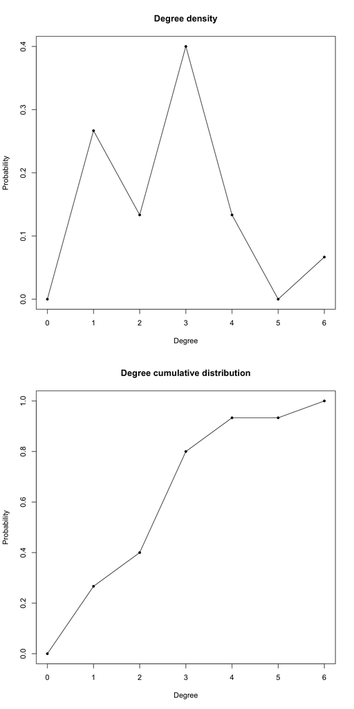

```r
par(mfrow=c(2,1))
plot(0:max(degree(FLOp)), degree_distribution(FLOp),pch=20,main="Degree density",xlab="Degree",ylab="Probability",type="o")
plot(0:max(degree(FLOp)), TrDD,pch=20,main="Degree cumulative distribution",xlab="Degree",ylab="Probability",type="o")
```

The neighborhood of a node is computed with **neighbors**

```r
neighbors(FLOp,v="Medici")
```

```
## + 6/15 vertices, named:
## [1] Acciaiuoli Albizzi    Barbadori  Ridolfi    Salviati   Tornabuoni
```

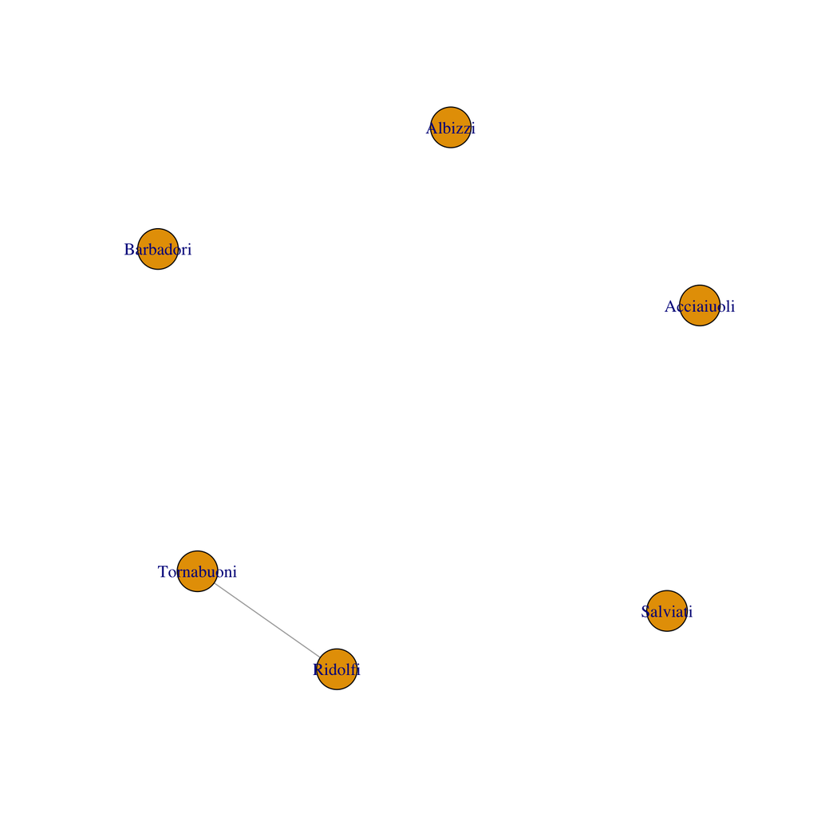

```r
plot(induced_subgraph(FLOp,v=as.vector(neighbors(FLOp,v="Medici"))))
```

The degree assortativity can be computed with **assortativity_degree**:

```r
round(assortativity_degree(FLOp),4)
```

```
## [1] -0.3748
```

The coreness of each node can be computed with **coreness**

```r
coreness(FLOp)
```

```
##   Acciaiuoli      Albizzi    Barbadori     Bischeri   Castellani
##            1            2            2            2            2
##       Ginori     Guadagni Lamberteschi       Medici        Pazzi
##            1            2            1            2            1
##      Peruzzi      Ridolfi     Salviati      Strozzi   Tornabuoni
##            2            2            1            2            2
```

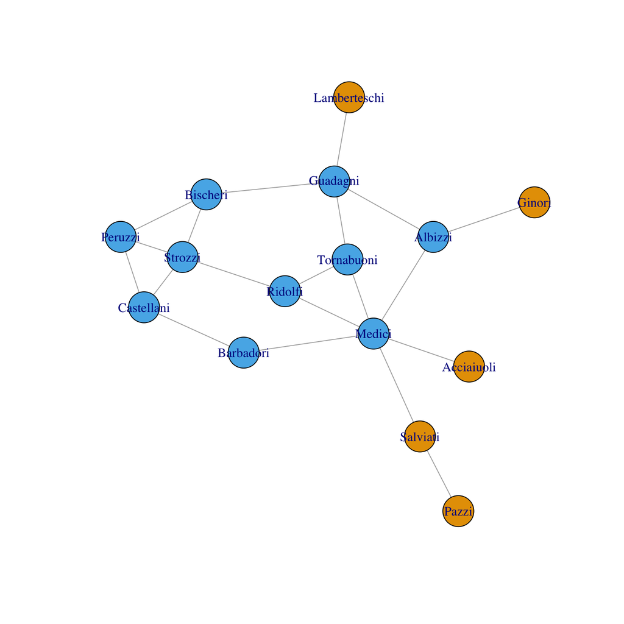

```r
plot(FLOp,vertex.color=coreness(FLOp))
```

## Indices related to distances

The matrix of distances between pairs of nodes is

```r
distances(FLOp)
```

|  | Acciaiuoli | Albizzi | Barbadori | Bischeri | Castellani | Ginori | Guadagni | Lamberteschi | Medici | Pazzi | Peruzzi | Ridolfi | Salviati | Strozzi | Tornabuoni |
| --- | --- | --- | --- | --- | --- | --- | --- | --- | --- | --- | --- | --- | --- | --- | --- |
| Acciaiuoli | 0 | 2 | 2 | 4 | 3 | 3 | 3 | 4 | 1 | 3 | 4 | 2 | 2 | 3 | 2 |
| Albizzi | 2 | 0 | 2 | 2 | 3 | 1 | 1 | 2 | 1 | 3 | 3 | 2 | 2 | 3 | 2 |
| Barbadori | 2 | 2 | 0 | 3 | 1 | 3 | 3 | 4 | 1 | 3 | 2 | 2 | 2 | 2 | 2 |
| Bischeri | 4 | 2 | 3 | 0 | 2 | 3 | 1 | 2 | 3 | 5 | 1 | 2 | 4 | 1 | 2 |
| Castellani | 3 | 3 | 1 | 2 | 0 | 4 | 3 | 4 | 2 | 4 | 1 | 2 | 3 | 1 | 3 |
| Ginori | 3 | 1 | 3 | 3 | 4 | 0 | 2 | 3 | 2 | 4 | 4 | 3 | 3 | 4 | 3 |
| Guadagni | 3 | 1 | 3 | 1 | 3 | 2 | 0 | 1 | 2 | 4 | 2 | 2 | 3 | 2 | 1 |
| Lamberteschi | 4 | 2 | 4 | 2 | 4 | 3 | 1 | 0 | 3 | 5 | 3 | 3 | 4 | 3 | 2 |
| Medici | 1 | 1 | 1 | 3 | 2 | 2 | 2 | 3 | 0 | 2 | 3 | 1 | 1 | 2 | 1 |
| Pazzi | 3 | 3 | 3 | 5 | 4 | 4 | 4 | 5 | 2 | 0 | 5 | 3 | 1 | 4 | 3 |
| Peruzzi | 4 | 3 | 2 | 1 | 1 | 4 | 2 | 3 | 3 | 5 | 0 | 2 | 4 | 1 | 3 |
| Ridolfi | 2 | 2 | 2 | 2 | 2 | 3 | 2 | 3 | 1 | 3 | 2 | 0 | 2 | 1 | 1 |
| Salviati | 2 | 2 | 2 | 4 | 3 | 3 | 3 | 4 | 1 | 1 | 4 | 2 | 0 | 3 | 2 |
| Strozzi | 3 | 3 | 2 | 1 | 1 | 4 | 2 | 3 | 2 | 4 | 1 | 1 | 3 | 0 | 2 |
| Tornabuoni | 2 | 2 | 2 | 2 | 3 | 3 | 1 | 2 | 1 | 3 | 3 | 1 | 2 | 2 | 0 |

The average distance is

```r
round(mean_distance(FLOp),4)
```

```
## [1] 2.4857
```

Its diameter and radius are

```r
diameter(FLOp)
```

```
## [1] 5
```

```r
radius(FLOp)
```

```
## [1] 3
```

The eccentricities can be computed with the **eccentricity** function:

```r
round(sort(eccentricity(FLOp),decreasing=TRUE),4)
```

```
##     Bischeri Lamberteschi        Pazzi      Peruzzi   Acciaiuoli
##            5            5            5            5            4
##    Barbadori   Castellani       Ginori     Guadagni     Salviati
##            4            4            4            4            4
##      Strozzi      Albizzi       Medici      Ridolfi   Tornabuoni
##            4            3            3            3            3
```

```r
round(eccentricity(FLOp,vids="Medici"),4)
```

```
## Medici
##      3
```

The h-neighborhoods can be computed with the function **ego** and parameter **order** set to h

```r
ego(FLOp,order=2,nodes="Medici")
```

```
## [[1]]
## + 12/15 vertices, named:
##  [1] Medici     Acciaiuoli Albizzi    Barbadori  Ridolfi    Salviati
##  [7] Tornabuoni Ginori     Guadagni   Castellani Strozzi    Pazzi
```

To compute the relative hop plot function we can do the following:

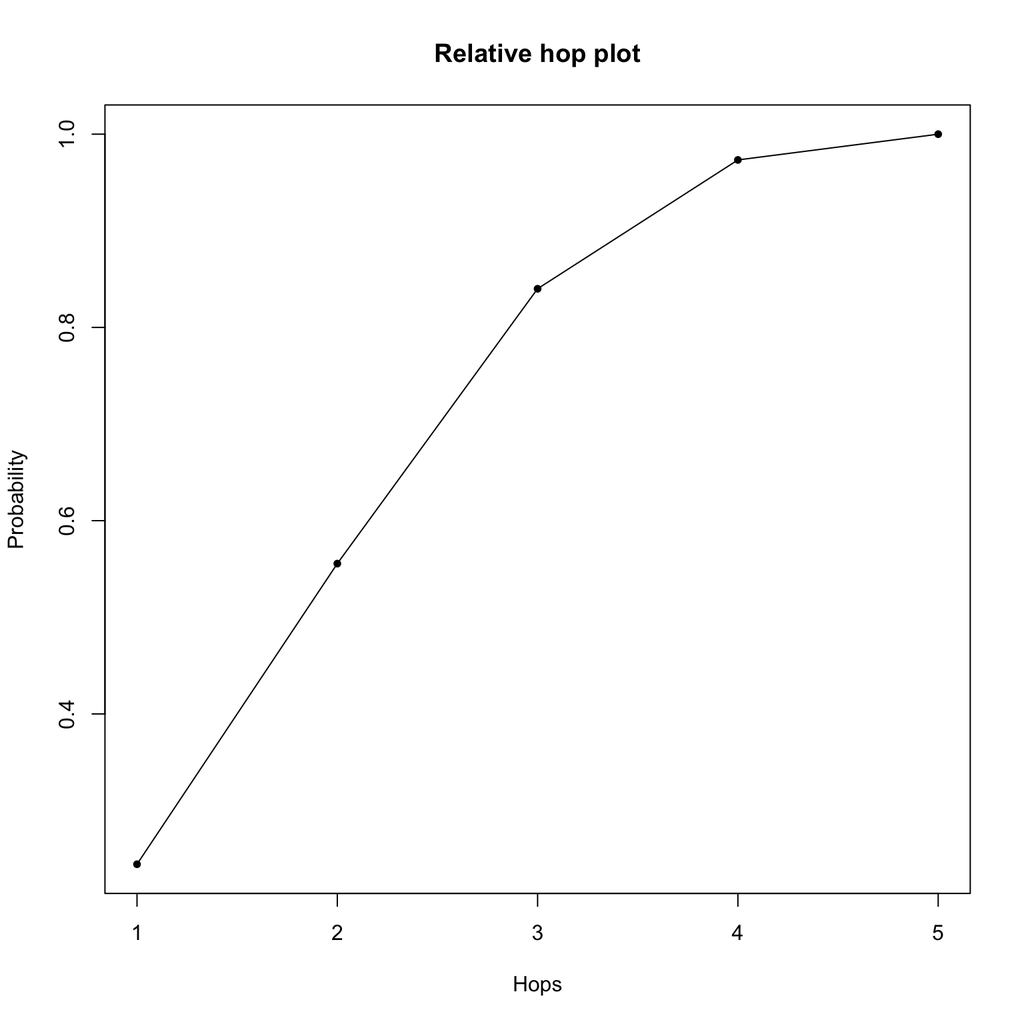

```r
rel.hop.plot=function(G){
F=function(x){length(unlist(ego(G,order=x,nodes=V(G))))/length(V(G))^2}
sapply(1:diameter(G),FUN=F)}
plot(rel.hop.plot(FLOp),pch=20,main="Relative hop plot",xlab="Hops",ylab="Probability",type="o")
```

## Indices related to clustering and transitivity

The main function to compute clustering coefficients is **transitivity**: with **type=“local”** it gives the clustering coefficient of nodes; with **type=“average”**, the average clustering coefficient; and with **type=“global”**, the transitivity.

The clustering coefficient of the Medici:

```r
round(transitivity(FLOp, type="local",vids="Medici"),4)
```

```
## [1] 0.0667
```

The vector of clustering coefficients:

```r
TR=matrix(transitivity(FLOp, type="local"),nrow=1,byrow=TRUE)
dimnames(TR)[2]=list(VF)
round(TR,4)
```

| Acciaiuoli | Albizzi | Barbadori | Bischeri | Castellani | Ginori | Guadagni | Lamberteschi | Medici | Pazzi | Peruzzi | Ridolfi | Salviati | Strozzi | Tornabuoni |
| --- | --- | --- | --- | --- | --- | --- | --- | --- | --- | --- | --- | --- | --- | --- |
| NaN | 0 | 0 | 0.3333 | 0.3333 | NaN | 0 | NaN | 0.0667 | NaN | 0.6667 | 0.3333 | 0 | 0.3333 | 0.3333 |

The average clustering coefficient:

```r
round(transitivity(FLOp, type="average"),4)  #Not taking into account degree 1 nodes
```

```
## [1] 0.2182
```

```r
round(transitivity(FLOp, type="average",isolates="zero"),4)  #Setting c(v)=0 for degree 1 nodes
```

```
## [1] 0.16
```

The transitivity:

```r
round(transitivity(FLOp),4)
```

```
## [1] 0.1915
```

As far a the edges’ support, we can compute it as follows. First, compute the triangles in the graph

```r
tr=triangles(FLOp)
tr
```

```
## + 9/15 vertices, named:
## [1] Medici     Ridolfi    Tornabuoni Strozzi    Bischeri   Peruzzi
## [7] Strozzi    Castellani Peruzzi
```

And now we can obtain the list of edges in triangles, with multiplicities. Its frequency table will be the support of each supported edge

```r
edg.tr=function(x){E(FLOp,path=c(x,x[1]))}
edges=tapply(tr,rep(1:(length(tr)/3),each = 3),FUN=edg.tr)
EF[unlist(edges)]
```

```
## [1] "Medici|Ridolfi"     "Ridolfi|Tornabuoni" "Medici|Tornabuoni"
## [4] "Bischeri|Strozzi"   "Bischeri|Peruzzi"   "Peruzzi|Strozzi"
## [7] "Castellani|Strozzi" "Castellani|Peruzzi" "Peruzzi|Strozzi"
```

```r
Supps=table(EF[unlist(edges)])
Supps
```

| Bischeri\|Peruzzi | Bischeri\|Strozzi | Castellani\|Peruzzi | Castellani\|Strozzi | Medici\|Ridolfi | Medici\|Tornabuoni | Peruzzi\|Strozzi | Ridolfi\|Tornabuoni |
| --- | --- | --- | --- | --- | --- | --- | --- |
| 1 | 1 | 1 | 1 | 1 | 1 | 2 | 1 |

Finally, the average support coefficient can be computed by means of

```r
round(length(tr)/m,4)
```

```
## [1] 0.45
```